# Predictin Academic Probation

Patrick Wynne

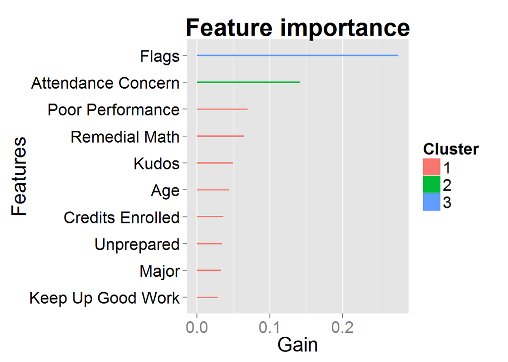

```r
ModelFTF <- glm(Probation ~ LimitedEnglish + `Credits Enrolled` +
                        DelayEnteringCollege +
                        RemedialWriting +
                        `Remedial Math` +
                        `Attendance Concern` + DangerofFailing + `Poor Performance` + Unprepared +
                        `Keep Up Good Work` +
                        OutstandingPerformance + ShowingImprovement +
                        Al + CW,
                data = training,
                family = "binomial")

ModelFTFNoEas <- glm(Probation ~ LimitedEnglish + `Credits Enrolled` +
                        DelayEnteringCollege +
                        RemedialWriting +
                        `Remedial Math`,
                data = training,
                family = "binomial")



train <- training
test <- testing

feature.names <- names(train)[2:ncol(train)-1]

dtrain <- xgb.DMatrix(data = data.matrix(train[,feature.names]), label=train$Probation)
dtest <- xgb.DMatrix(data = data.matrix(test[,feature.names]), label=test$Probation)

watchlist <- list(train=dtrain, test=dtest)

set.seed(1337)

bst <- xgb.train(data=dtrain,
                 params = list(max_depth         = 3,  # maximum depth of tree
                               eta              = 0.01,      # step size shrinkage
                               gamma             = 0,      # minimum loss reduction
                               subsample         = .9, # part of data instances to grow tree
                               colsample_bytree  = .5,
                               min_child_weight  = 0),
                 nround=1500,
                 watchlist=watchlist,
                 objective = "binary:logistic",
                 eval_metric = "auc")

importance_matrix <- xgb.importance(feature.names, model = bst)

importance_matrixR1 <- importance_matrix[1:10, ]

xgb.plot.importance(importance_matrixR1) + theme(text = element_text(size=20)) +
        theme(axis.text.y=element_text(colour="black"))
```

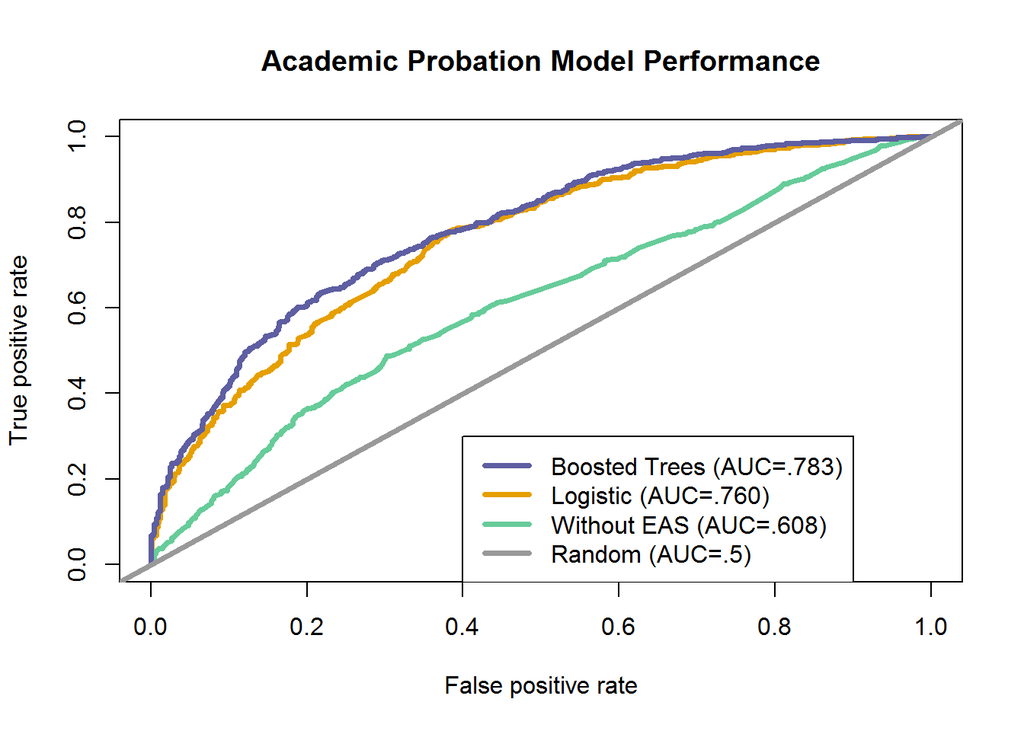

```r
testing$Probationxgboost <- predict(bst, data.matrix(testing[feature.names]))
predxgboost <- prediction(testing$Probationxgboost, testing$Probation)
perfxgboost <- performance(predxgboost,"tpr","fpr")
auc(testing$Probation, testing$Probationxgboost)

testing$ProbationLogit <- predict(ModelFTF, testing, type = "response")

predlogit <- prediction(testing$ProbationLogit, testing$Probation)
perflogit <- performance(predlogit,"tpr","fpr")
auc(testing$Probation, testing$ProbationLogit)

testing$ProbationLogitnoeas <- predict(ModelFTFNoEas, testing, type = "response")

predlogitNoEAS <- prediction(testing$ProbationLogitnoeas, testing$Probation)
perflogitNoEAS <- performance(predlogitNoEAS,"tpr","fpr")
auc(testing$Probation, testing$ProbationLogitnoeas)
```

R version 3.1.3 (2015-03-09) Platform: x86_64-w64-mingw32/x64 (64-bit) Running under: Windows 7 x64 (build 7601) Service Pack 1

locale: [1] LC_COLLATE=English_United States.1252 [2] LC_CTYPE=English_United States.1252  
[3] LC_MONETARY=English_United States.1252 [4] LC_NUMERIC=C  
[5] LC_TIME=English_United States.1252

attached base packages: [1] stats graphics grDevices utils datasets methods base